# Breastfeeding Trends and Economic Factors: A Global Perspective

## Breastfeeding Trends Over Time (2000–2022)

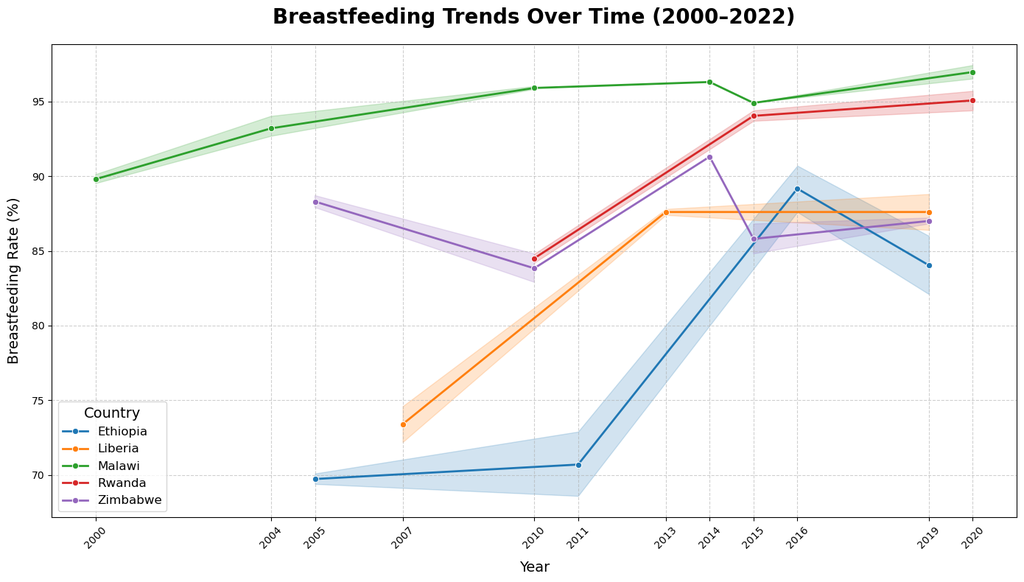

### Code

**Show Code**

```python
# Line Chart
selected_countries = ['Malawi', 'Rwanda', 'Ethiopia','Zimbabwe', 'Liberia']

# Filter data
trend_data = breastfeeding_data[
    breastfeeding_data['country'].isin(selected_countries)
]

# Plot
plt.figure(figsize=(14, 8))
sns.lineplot(
    data=trend_data,
    x='time_period',
    y='obs_value',
    hue='country',
    marker='o',
    linewidth=2
)

# Title and labels
plt.title('Breastfeeding Trends Over Time (2000–2022)', fontsize=20, weight='bold', pad=20)
plt.xlabel('Year', fontsize=14, labelpad=10)
plt.ylabel('Breastfeeding Rate (%)', fontsize=14, labelpad=10)

# Tidy x-ticks
plt.xticks(sorted(trend_data['time_period'].unique()), rotation=45)

# Nice grid
plt.grid(True, linestyle='--', alpha=0.6)

# Legend
plt.legend(title='Country', fontsize=12, title_fontsize=14)

plt.tight_layout()
plt.show()
```

## Breastfeeding Rates vs Sanitation Access (Scatterplot with Regression Line)

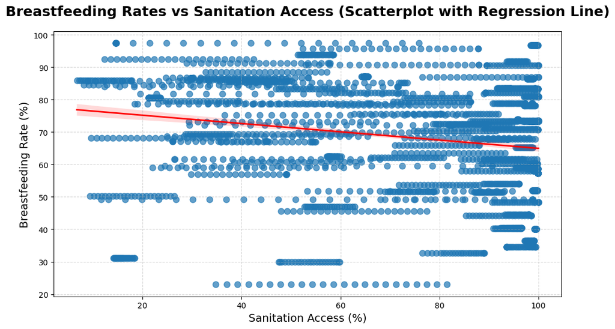

**Insight:**  
- The **scatterplot with regression line** indicates a *slight negative correlation* between *sanitation access* and *breastfeeding rates*.  
- Surprisingly, countries with *higher sanitation access* are **not necessarily the ones with the highest breastfeeding rates**.  
- This suggests that **cultural practices, awareness programs, and healthcare support** have a stronger impact on breastfeeding habits than sanitation infrastructure alone.  
- **Policy efforts** aimed at improving breastfeeding must focus on **social, cultural, and educational initiatives**, not just on general infrastructure improvements.

### Code

**Show Code**

```python
merged_data = pd.merge(
    breastfeeding_latest[['country_standardized', 'obs_value']],
    indi2[['country', 'obs_value']],
    how='inner',
    left_on='country_standardized',
    right_on='country'
)

merged_data = merged_data.rename(columns={
    'obs_value_x': 'Breastfeeding Rate (%)',
    'obs_value_y': 'Sanitation Access (%)'
})

merged_data = merged_data.dropna()

plt.figure(figsize=(10, 6))

sns.regplot(
    data=merged_data,
    x='Sanitation Access (%)',
    y='Breastfeeding Rate (%)',
    scatter_kws={'s': 60, 'alpha': 0.7},
    line_kws={'color': 'red', 'linewidth': 2}
)

plt.title('Breastfeeding Rates vs Sanitation Access (Scatterplot with Regression Line)', fontsize=18, weight='bold', pad=20)
plt.xlabel('Sanitation Access (%)', fontsize=14)
plt.ylabel('Breastfeeding Rate (%)', fontsize=14)

plt.grid(True, linestyle='--', alpha=0.5)
plt.tight_layout()
plt.show()
```

## Top 20 Countries by Breastfeeding Rates (2000–2022)

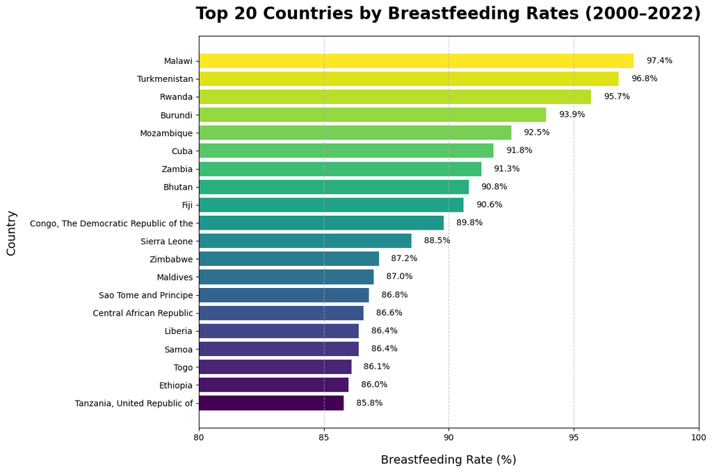

**Insight:**  
- **Malawi** ranks at the top with a *breastfeeding rate of 97.4%*, followed closely by **Turkmenistan** and **Rwanda**.  
- Many of the top performers are *low-to-middle income countries*, demonstrating that *high breastfeeding rates* are achievable regardless of *economic status*.  
- **Cultural factors, community healthcare interventions, and local traditions** seem to have played a **major role** in sustaining *exclusive breastfeeding practices*.  
- These top countries serve as **positive case studies** for nations aiming to improve their breastfeeding rates through **community-based strategies** rather than just healthcare expenditure.

### Code

**Show Code**

```python
top_countries = breastfeeding_latest.sort_values(by='obs_value', ascending=False).head(20)

plt.figure(figsize=(12, 8))
bars = plt.barh(
    top_countries['country_standardized'],
    top_countries['obs_value'],
    color=plt.cm.viridis_r(np.linspace(0, 1, len(top_countries)))
)

for bar in bars:
    width = bar.get_width()
    plt.text(
        width + 0.5,
        bar.get_y() + bar.get_height()/2,
        f'{width:.1f}%',
        va='center',
        ha='left',
        fontsize=10
    )

plt.title('Top 20 Countries by Breastfeeding Rates (2000–2022)', fontsize=20, weight='bold', pad=20)
plt.xlabel('Breastfeeding Rate (%)', fontsize=14, labelpad=15)
plt.ylabel('Country', fontsize=14, labelpad=15)

plt.xlim(80, 100)
plt.xticks(np.arange(80, 101, 5))

plt.grid(axis='x', linestyle='--', alpha=0.7)

plt.gca().invert_yaxis()

plt.tight_layout()
plt.show()
```

# Conclusion

To ensure continued progress, governments, NGOs, and global health agencies must prioritize **culturally sensitive, education-driven initiatives** while supporting infrastructure development.  
In doing so, we can work towards a future where **every child benefits from the life-saving advantages of early and sustained breastfeeding**, regardless of their place of birth.